# W3 STAT5003 RMD

Victor Z. Nygaard, vnyg7406

Last compiled on 28. januar, 2023

# 1

We may simulate the samples of Gaussian variables and plot the data on density scale as such:

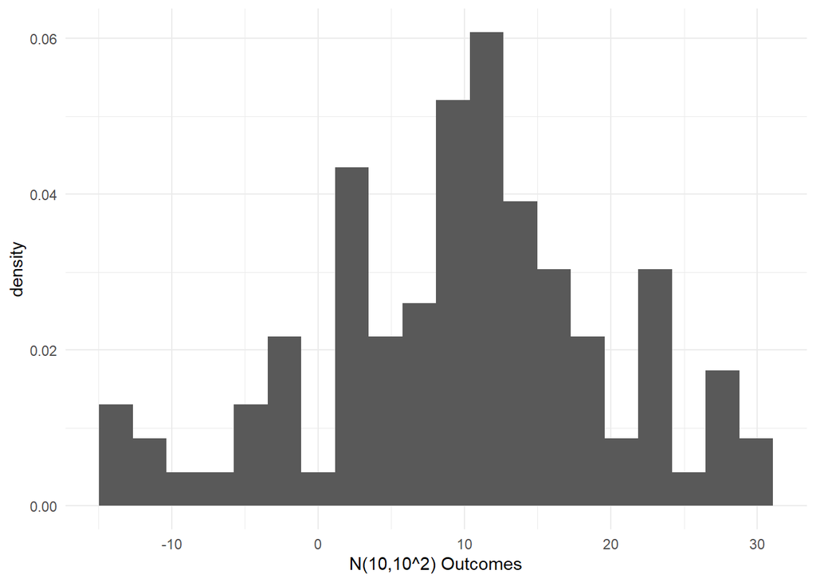

```r
n <- 10^2
mu <- 10
sigma <- 10
gau <- rnorm(n = n, mean = mu, sd = sigma)
gau %>% as.data.frame %>% ggplot() + geom_histogram(bins = 20, aes(x = gau, y = ..density..)) + xlab("N(10,10^2) Outcomes")
```

We note that the above simulation of Gaussian variables was carried out using a default seed of $314$ implemented in the setup chuck of my RMD template. Setting a new seed, we may simulate new data:

```r
stu_id <- 520540446
set.seed(stu_id)
gau <- rnorm(n, mu,sigma)
rm(.Random.seed, envir=globalenv()) #reset seed
set.seed(stu_id) #set seed again.
#simulate again,
#test for whether all values of gau == rnorm(10^2, 10, 10) are T
identical(gau, rnorm(n, mu, sigma))
```

```
## [1] TRUE
```

We will simulate $100$ iid. outcomes of $\mathcal{N}\mathopen{}\left({{\mu},{10^2}}\right)\mathclose{}$ for each of $\mu = 1,2,\ldots, 20$

```r
muVec <- seq(1,20,1)
normalMatrix <- matrix(NA, n, length(muVec))
#!!!careful with scoping here, calling for (mu in muVec, changes the global mu for some reason)
for (m in muVec) {
   normalMatrix[,m] <- rnorm(n, m, sigma)
}
```

For each $\mu$ we calculate the log-likelihood that this iid data is derived from $\mathcal{N}\mathopen{}\left({{10},{10}}\right)\mathclose{}.$ We do this two different ways, as shown:

```r
logLike <- apply(apply(normalMatrix,2,dnorm, mean = mu, sd = sigma, log = T), 2, sum) #using dnorm

#using loglikelihood function
f <- function(x, mu, sigma) {
   -n/2*log(2*pi*sigma^2)-1/(2*sigma^2)*sum((x-mu)^2)
}
identical(logLike, apply(normalMatrix, 2, f, mu = 10, sigma = 10)) #is the result the same? -> 'No'
```

```
## [1] FALSE
```

```r
#really? The results are not the same?
max(logLike-apply(normalMatrix, 2, f, mu = 10, sigma = 10)) # they ARE the same up to numerical error.
```

```
## [1] 0
```

In particular, for $\mu = 8$ we get a loglikelihood of -371.6453703. We may also plot the loglikelihoods:

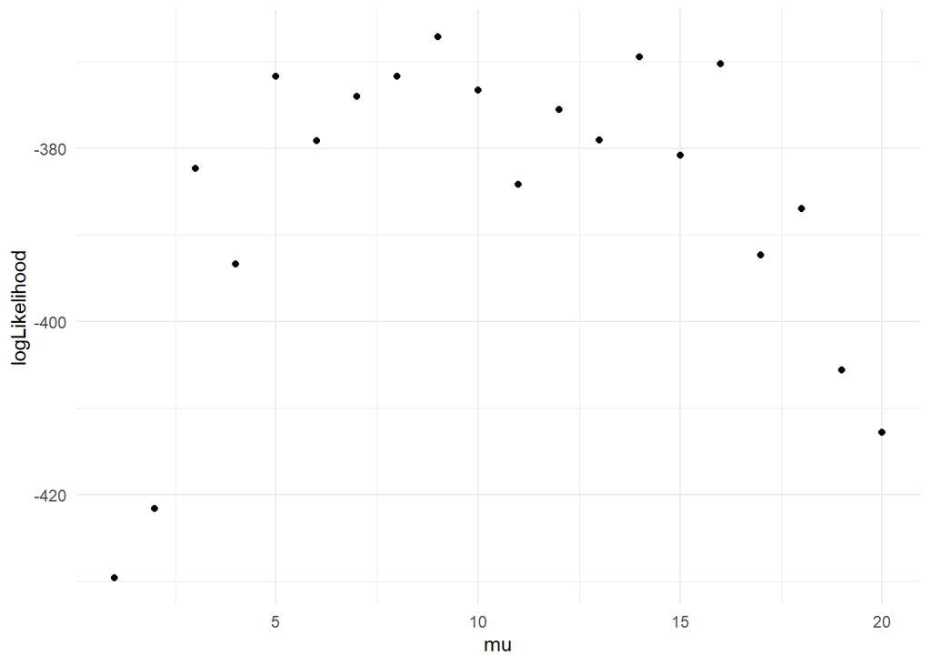

```r
muLogLikeDf <- data.frame(mu = muVec,logLikelihood = logLike)
muLogLikeDf %>% ggplot() + geom_point(aes(x = mu, y = logLikelihood))
```

Note that based on the plot, we get the maximum loglikelihood value at $\mu=9$ for $n=100$ though we know from general theory that likelihood will guess correctly asymptotically.

# 2

We load in the data:

```r
height <- read_table("../Data/height.txt")
head(height)
```

```
## # A tibble: 6 × 2
##   ID    Height_m
##   <chr>    <dbl>
## 1 i1        1.58
## 2 i2        1.62
## 3 i3        1.57
## 4 i4        1.69
## 5 i5        1.63
## 6 i6        1.57
```

We plot the data in a histogram for $5, 10, 20, 30$ bins respectively.

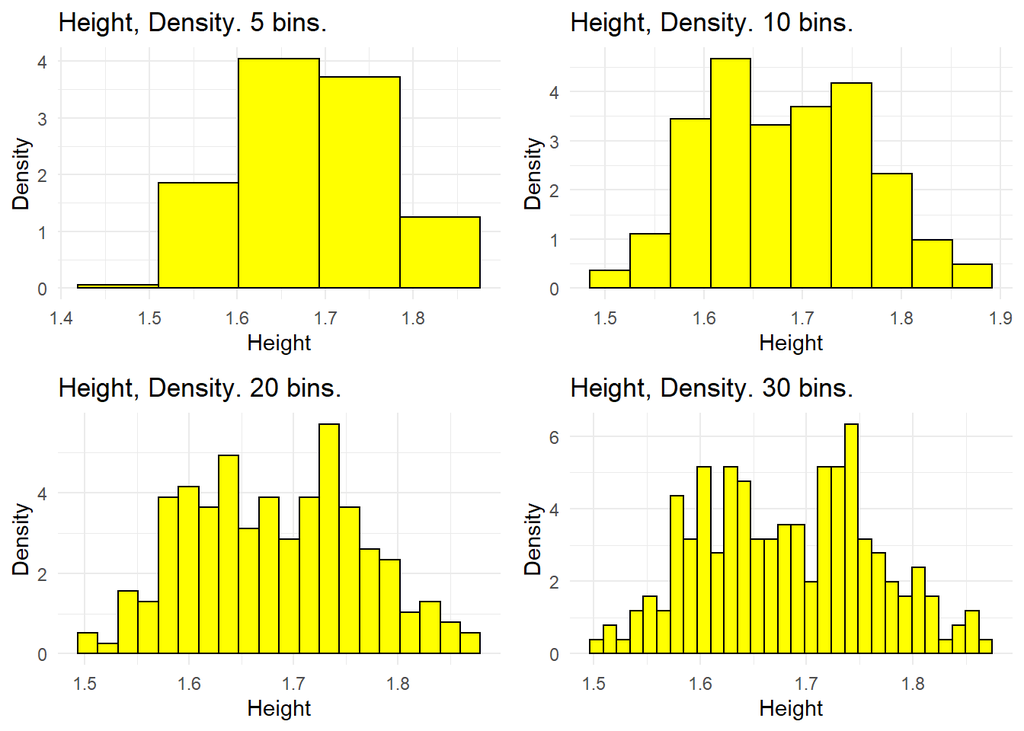

```r
p <- height %>% dplyr::select(Height_m) %>% ggplot(aes(x = Height_m, y = ..density..)) + xlab("Height") + ylab("Density")
p1 <- p + geom_histogram(bins = 30, colour = "black", fill = "yellow") + ggtitle("Height, Density. 30 bins.")
p2 <- p + geom_histogram(bins = 5, colour = "black", fill = "yellow") + ggtitle("Height, Density. 5 bins.")
p3 <- p + geom_histogram(bins = 10, colour = "black", fill = "yellow") + ggtitle("Height, Density. 10 bins.")
p4 <- p + geom_histogram(bins = 20, colour = "black", fill = "yellow") + ggtitle("Height, Density. 20 bins.")
grid.arrange(p2,p3,p4,p1,ncol = 2)
```

We use `density` to do kernel density estimation

```r
#?density #checking info on the density function
gKernel <- height %>% dplyr::select(Height_m) %>% as.matrix %>% as.numeric %>% density(kernel = "gaussian")
eKernel <- height %>% dplyr::select(Height_m) %>% as.matrix %>% as.numeric %>% density(kernel = "epanechnikov")
tKernel <- height %>% dplyr::select(Height_m) %>% as.matrix %>% as.numeric %>% density(kernel = "triangular")
```

We may plot the results:

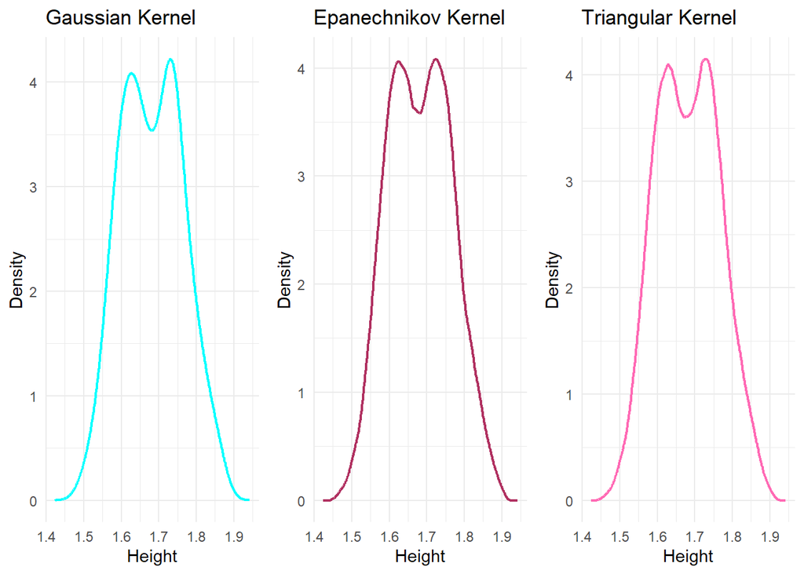

```r
Kernel_df <- function(K) data.frame(x = K$x, y = K$y)
empty_p <- ggplot() + xlab("Height") + ylab("Density")
g_plot <- empty_p + geom_line(Kernel_df(gKernel), mapping = aes(x = x, y = y), colour = "cyan", size = 0.8) + ggtitle("Gaussian Kernel")
e_plot <- empty_p + geom_line(Kernel_df(eKernel), mapping = aes(x = x, y = y), colour = "maroon", size = 0.8) + ggtitle("Epanechnikov Kernel")
t_plot <- empty_p + geom_line(Kernel_df(tKernel), mapping = aes(x = x, y = y), colour = "hotpink", size = 0.8) + ggtitle("Triangular Kernel")

grid.arrange(g_plot, e_plot, t_plot, ncol = 3)
```

We may also plot the estimated curves together on the same plot, as well as with the data, this time using `stat_density`’s kernel function with default parameters.

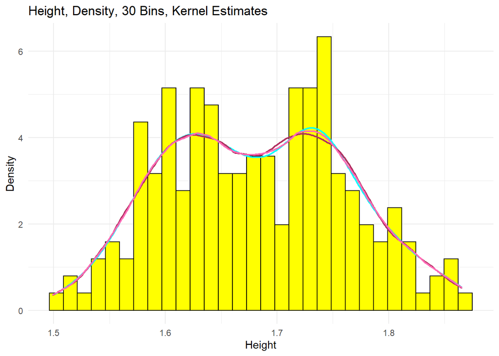

```r
p1 + geom_density(kernel = "gaussian", colour = "cyan", size = 0.8, alpha = 0.5, show.legend = T) +
   geom_density(kernel = "epanechnikov", colour = "maroon", size = 0.8, alpha = 0.5, show.legend = T) +
   geom_density(kernel = "triangular", colour = "hotpink", size = 0.8, alpha = 0.5, show.legend = T) + ggtitle("Height, Density, 30 Bins, Kernel Estimates")
```

We may compute an estimate of the probability that a person is higher than $1.7m$ using each of the kernel density estimators:

```r
integrate(approxfun(gKernel), 1.7, max(gKernel$x))
```

```
## 0.4314333 with absolute error < 3.1e-05
```

```r
integrate(approxfun(eKernel), 1.7, max(eKernel$x))
```

```
## 0.4304278 with absolute error < 2.6e-05
```

```r
integrate(approxfun(tKernel), 1.7, max(tKernel$x))
```

```
## 0.4305338 with absolute error < 3.6e-05
```

and compare this to the empirical estimate

```r
mean(height$Height_m>1.7)
```

```
## [1] 0.435
```

We may load in the `stats4` library.

```r
library(stats4)
ff <- function(mu,sigma) {
   return(-f(height$Height_m, mu, sigma))
}
mle_fit <- mle(ff, start = list(mu = 1, sigma = 1))
coef(mle_fit)
```

```
##        mu     sigma
## 1.6817770 0.1143212
```

Under the iid normality assumption implicitly implemented in using `mle` on `ff`, `mle` optimises `ff` for the parameters `mu` and `sigma`, starting in `mu = 1` and `sigma = 1`. The resulting MLE estimates for $\mu$ and $\sigma$ are `coef(mle_fit)[1]` and `coef(mle_fit)[2]`, as shown above.

# 3

We simulate $100$ values from $\mathcal{N}\mathopen{}\left({{0},{1}}\right)\mathclose{}$ and write our ISE-calculating function `ISECalc` that takes in the required parameters; the data to ‘train’ the kernel, the bandwidth $h$ to be used in the kernel-specification, the desired kernel, and the range over which to calculate the ISE. The function outputs an ISE-estimate.

```r
stdNorm <- rnorm(100)
ISECalc <- function(data, h, f, kernel = "triangular", range = range(data)) {
   kDens <- density(data, bw = h, kernel = kernel, n = 512, from = range[1], to = range[2])
   fapp <- approxfun(kDens)
   fDiffSq <- function(x) (fapp(x)-f(x))^2
   return(integrate(fDiffSq, range[1], range[2])[[1]])
}
```

Based on this function, we may calculate the ISE for a range of $h$ values from $0.05$ up to $2$, as specified `hVec` below. In our example, we will use the triangular kernel. We note the restriction of the integration range from $-\infty, \infty$ to $-3,3$ as this is were the far majority of support lies for standard normal random variables. From this, we may plot the resulting relation as a scatterplot. We have high-lighted the minimal $h$ value

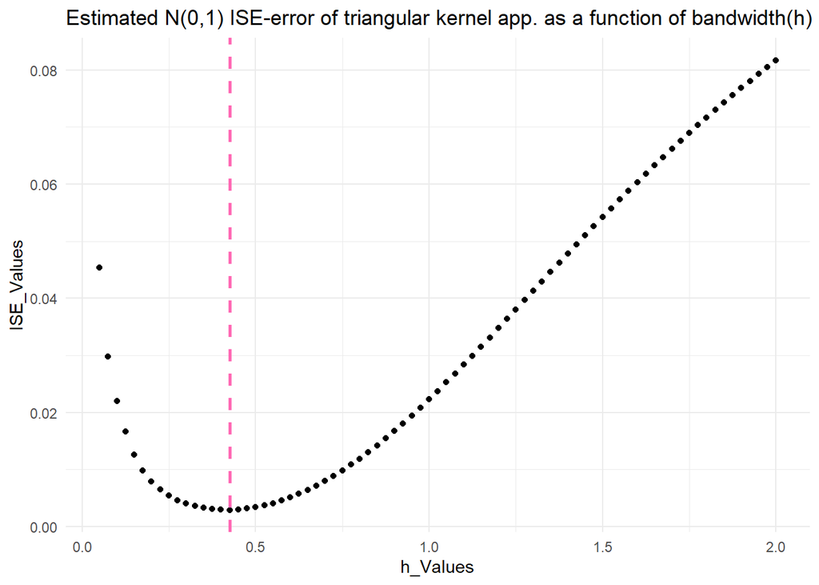

```r
hVec <- seq(0.05,2,0.025)
ISEVal <- c()
for (i in 1:length(hVec)) {
   ISEVal[i] <- ISECalc(stdNorm, hVec[i], dnorm, "triangular", c(-3, 3))
}
ggplot(data.frame(h_Values = hVec, ISE_Values = ISEVal), aes(x = h_Values, y = ISE_Values)) +
   geom_point() +
   ggtitle("Estimated N(0,1) ISE-error of triangular kernel app. as a function of bandwidth(h)") +
   geom_vline(aes(xintercept = hVec[which.min(ISEVal)]), linetype = "dashed", size = 1, colour = "hotpink")
```

Loading in the $\text{argmin}$ value of $h,$ we may plot the estimated triangular kernel density against the true standard normal one

[figure not shown]

```r
h05_tdens <- density(stdNorm, bw = hVec[which.min(ISEVal)], n = 512, kernel = "triangular")

kernel_stdnormal_df <- data.frame(simVal = seq(-3,3,0.01), densVal = dnorm(seq(-3,3,0.01)),
                                  Density_type = rep("std_normal",length(seq(-3,3,0.01)))) %>%
   rbind(data.frame(simVal = h05_tdens$x, densVal = h05_tdens$y,
                    Density_type = rep("triangular_kernel", length(h05_tdens$y))))
kernel_stdnormal_df %>% ggplot(aes(x = simVal, y = densVal, colour = Density_type)) + geom_line(size = 1.2, alpha = 0.6) + labs(x = "N(0,1) outcome", y = "Density", title = "True N(0,1) and est. triangular kernel density for 'optimal' bandwidth h = 0.5")
```

We see that the kernel mimics the standard normal density rather well, as based on $100$ samples.

While the method employed above to find an optimal bandwidth value is superior to guessing, or going with a fixed default one may also note that `?stats::bw.ucv`, `?stats::bw.nrd0(x)`,… reveal that there are alternative methods of choosing a default bandwidth value that are smarter than picking some fixed value. Attempting with the biased Gaussian cross-validated `bw.bcv` we may plot the result

```r
bw <- bw.bcv(height$Height_m)
```

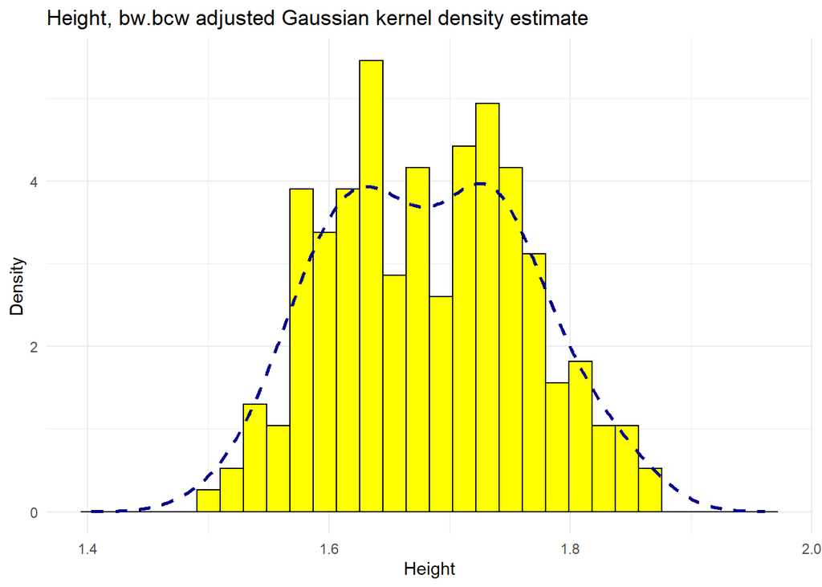

```r
bwDensity <- density(height$Height_m, bw = bw, kernel = "gaussian")
bwDensity_df <- data.frame(x = bwDensity$x, y = bwDensity$y)
p1 + geom_line(data = bwDensity_df, aes(x=x, y=y),colour = "darkblue", size = 1, linetype = "dashed") + labs(title = "Height, bw.bcw adjusted Gaussian kernel density estimate", x = "Height", y = "Density")
```